# Stress and Lifestyle Factors Analysis

This project analyzes the correlations between stress levels and various lifestyle factors using a dataset titled "Sleep_health_and_lifestyle_dataset.csv."

## Project Overview

The primary goal of this project is to explore how different lifestyle factors, such as sleep duration, quality of sleep, exercise levels, heart rate, and daily steps correlate with stress levels.

## Results

The final output of the analysis includes:

- Visualizations that illustrate the distribution and relationships between different lifestyle factors and stress levels.
- A correlation matrix that quantifies how strongly each factor is correlated with stress levels.
- A summary that highlights which lifestyle factors are most strongly associated with stress levels, offering insights into how lifestyle choices might impact stress.

## Acknowledgments

The dataset used in this project was sourced from kaggle.com. Inspiration for this project came from the intersection of data analysis and mental health.

```python
import pandas as pd
import matplotlib.pyplot as plt
import numpy as np
import seaborn as sns
import warnings

warnings.filterwarnings("ignore", category=FutureWarning)
%matplotlib inline
```

```python
health_df = pd.read_csv('Sleep_health_and_lifestyle_dataset.csv')
health_df.head()
```

|  | Person ID | Gender | Age | Occupation | Sleep Duration | Quality of Sleep | Physical Activity Level | Stress Level | BMI Category | Blood Pressure | Heart Rate | Daily Steps | Sleep Disorder |
| --- | --- | --- | --- | --- | --- | --- | --- | --- | --- | --- | --- | --- | --- |
| 0 | 1 | Male | 27 | Software Engineer | 6.1 | 6 | 42 | 6 | Overweight | 126/83 | 77 | 4200 | NaN |
| 1 | 2 | Male | 28 | Doctor | 6.2 | 6 | 60 | 8 | Normal | 125/80 | 75 | 10000 | NaN |
| 2 | 3 | Male | 28 | Doctor | 6.2 | 6 | 60 | 8 | Normal | 125/80 | 75 | 10000 | NaN |
| 3 | 4 | Male | 28 | Sales Representative | 5.9 | 4 | 30 | 8 | Obese | 140/90 | 85 | 3000 | Sleep Apnea |
| 4 | 5 | Male | 28 | Sales Representative | 5.9 | 4 | 30 | 8 | Obese | 140/90 | 85 | 3000 | Sleep Apnea |

```python
health_df.shape
```

```
(374, 13)
```

```python
health_df.info()
```

```
<class 'pandas.core.frame.DataFrame'>
RangeIndex: 374 entries, 0 to 373
Data columns (total 13 columns):
 #   Column                   Non-Null Count  Dtype
---  ------                   --------------  -----
 0   Person ID                374 non-null    int64
 1   Gender                   374 non-null    object
 2   Age                      374 non-null    int64
 3   Occupation               374 non-null    object
 4   Sleep Duration           374 non-null    float64
 5   Quality of Sleep         374 non-null    int64
 6   Physical Activity Level  374 non-null    int64
 7   Stress Level             374 non-null    int64
 8   BMI Category             374 non-null    object
 9   Blood Pressure           374 non-null    object
 10  Heart Rate               374 non-null    int64
 11  Daily Steps              374 non-null    int64
 12  Sleep Disorder           155 non-null    object
dtypes: float64(1), int64(7), object(5)
memory usage: 38.1+ KB
```

```python
health_df.describe()
```

|  | Person ID | Age | Sleep Duration | Quality of Sleep | Physical Activity Level | Stress Level | Heart Rate | Daily Steps |
| --- | --- | --- | --- | --- | --- | --- | --- | --- |
| count | 374.000000 | 374.000000 | 374.000000 | 374.000000 | 374.000000 | 374.000000 | 374.000000 | 374.000000 |
| mean | 187.500000 | 42.184492 | 7.132086 | 7.312834 | 59.171123 | 5.385027 | 70.165775 | 6816.844920 |
| std | 108.108742 | 8.673133 | 0.795657 | 1.196956 | 20.830804 | 1.774526 | 4.135676 | 1617.915679 |
| min | 1.000000 | 27.000000 | 5.800000 | 4.000000 | 30.000000 | 3.000000 | 65.000000 | 3000.000000 |
| 25% | 94.250000 | 35.250000 | 6.400000 | 6.000000 | 45.000000 | 4.000000 | 68.000000 | 5600.000000 |
| 50% | 187.500000 | 43.000000 | 7.200000 | 7.000000 | 60.000000 | 5.000000 | 70.000000 | 7000.000000 |
| 75% | 280.750000 | 50.000000 | 7.800000 | 8.000000 | 75.000000 | 7.000000 | 72.000000 | 8000.000000 |
| max | 374.000000 | 59.000000 | 8.500000 | 9.000000 | 90.000000 | 8.000000 | 86.000000 | 10000.000000 |

```python
health_df.isna().sum()
```

```
Person ID                    0
Gender                       0
Age                          0
Occupation                   0
Sleep Duration               0
Quality of Sleep             0
Physical Activity Level      0
Stress Level                 0
BMI Category                 0
Blood Pressure               0
Heart Rate                   0
Daily Steps                  0
Sleep Disorder             219
dtype: int64
```

```python
health_df.fillna('None', inplace=True)
```

```python
health_df.isna().sum()
```

```
Person ID                  0
Gender                     0
Age                        0
Occupation                 0
Sleep Duration             0
Quality of Sleep           0
Physical Activity Level    0
Stress Level               0
BMI Category               0
Blood Pressure             0
Heart Rate                 0
Daily Steps                0
Sleep Disorder             0
dtype: int64
```

```python
health_df['Occupation'].value_counts()
```

```
Occupation
Nurse                   73
Doctor                  71
Engineer                63
Lawyer                  47
Teacher                 40
Accountant              37
Salesperson             32
Software Engineer        4
Scientist                4
Sales Representative     2
Manager                  1
Name: count, dtype: int64
```

```python
health_df.loc[health_df.Occupation == 'Software Engineer']
```

|  | Person ID | Gender | Age | Occupation | Sleep Duration | Quality of Sleep | Physical Activity Level | Stress Level | BMI Category | Blood Pressure | Heart Rate | Daily Steps | Sleep Disorder |
| --- | --- | --- | --- | --- | --- | --- | --- | --- | --- | --- | --- | --- | --- |
| 0 | 1 | Male | 27 | Software Engineer | 6.1 | 6 | 42 | 6 | Overweight | 126/83 | 77 | 4200 | None |
| 5 | 6 | Male | 28 | Software Engineer | 5.9 | 4 | 30 | 8 | Obese | 140/90 | 85 | 3000 | Insomnia |
| 84 | 85 | Male | 35 | Software Engineer | 7.5 | 8 | 60 | 5 | Normal Weight | 120/80 | 70 | 8000 | None |
| 92 | 93 | Male | 35 | Software Engineer | 7.5 | 8 | 60 | 5 | Normal Weight | 120/80 | 70 | 8000 | None |

```python
health_df['Gender'].value_counts()
```

```
Gender
Male      189
Female    185
Name: count, dtype: int64
```

```python
health_df['BMI Category'].unique()
```

```
array(['Overweight', 'Normal', 'Obese', 'Normal Weight'], dtype=object)
```

```python
health_df['BMI Category'] = health_df['BMI Category'].replace('Normal', 'Normal Weight')
```

```python
health_df['BMI Category'].unique()
```

```
array(['Overweight', 'Normal Weight', 'Obese'], dtype=object)
```

```python
health_df.groupby('Occupation').Age.min()
```

```
Occupation
Accountant              32
Doctor                  28
Engineer                32
Lawyer                  35
Manager                 45
Nurse                   29
Sales Representative    28
Salesperson             42
Scientist               33
Software Engineer       27
Teacher                 29
Name: Age, dtype: int64
```

```python
health_df['Sleep Disorder'].value_counts()
```

```
Sleep Disorder
None           219
Sleep Apnea     78
Insomnia        77
Name: count, dtype: int64
```

```python
health_df.describe()
```

|  | Person ID | Age | Sleep Duration | Quality of Sleep | Physical Activity Level | Stress Level | Heart Rate | Daily Steps |
| --- | --- | --- | --- | --- | --- | --- | --- | --- |
| count | 374.000000 | 374.000000 | 374.000000 | 374.000000 | 374.000000 | 374.000000 | 374.000000 | 374.000000 |
| mean | 187.500000 | 42.184492 | 7.132086 | 7.312834 | 59.171123 | 5.385027 | 70.165775 | 6816.844920 |
| std | 108.108742 | 8.673133 | 0.795657 | 1.196956 | 20.830804 | 1.774526 | 4.135676 | 1617.915679 |
| min | 1.000000 | 27.000000 | 5.800000 | 4.000000 | 30.000000 | 3.000000 | 65.000000 | 3000.000000 |
| 25% | 94.250000 | 35.250000 | 6.400000 | 6.000000 | 45.000000 | 4.000000 | 68.000000 | 5600.000000 |
| 50% | 187.500000 | 43.000000 | 7.200000 | 7.000000 | 60.000000 | 5.000000 | 70.000000 | 7000.000000 |
| 75% | 280.750000 | 50.000000 | 7.800000 | 8.000000 | 75.000000 | 7.000000 | 72.000000 | 8000.000000 |
| max | 374.000000 | 59.000000 | 8.500000 | 9.000000 | 90.000000 | 8.000000 | 86.000000 | 10000.000000 |

```python
activity_ranking = [25, 45, 60, 75, 90]
activity_rank_label = ['least active', 'below average active', 'above average active', 'most active']
```

```python
health_df['Activity Ranking'] = pd.cut(health_df['Physical Activity Level'], activity_ranking, labels=activity_rank_label)
health_df.sample(5)
```

|  | Person ID | Gender | Age | Occupation | Sleep Duration | Quality of Sleep | Physical Activity Level | Stress Level | BMI Category | Blood Pressure | Heart Rate | Daily Steps | Sleep Disorder | Activity Ranking |
| --- | --- | --- | --- | --- | --- | --- | --- | --- | --- | --- | --- | --- | --- | --- |
| 133 | 134 | Female | 38 | Accountant | 7.1 | 8 | 60 | 4 | Normal Weight | 115/75 | 68 | 7000 | None | below average active |
| 204 | 205 | Male | 43 | Engineer | 7.6 | 8 | 75 | 4 | Overweight | 122/80 | 68 | 6800 | None | above average active |
| 134 | 135 | Male | 38 | Lawyer | 7.3 | 8 | 60 | 5 | Normal Weight | 130/85 | 68 | 8000 | None | below average active |
| 92 | 93 | Male | 35 | Software Engineer | 7.5 | 8 | 60 | 5 | Normal Weight | 120/80 | 70 | 8000 | None | below average active |
| 54 | 55 | Male | 32 | Doctor | 6.0 | 6 | 30 | 8 | Normal Weight | 125/80 | 72 | 5000 | None | least active |

```python
worst_sleep = health_df.loc[(health_df['Sleep Duration'] <= 7.2) &
                    (health_df['Quality of Sleep'] <= 7)]
worst_sleep.shape[0]
```

```
158
```

```python
best_sleep = health_df.loc[(health_df['Sleep Duration'] > 7.2) &
                    (health_df['Quality of Sleep'] > 7)]
best_sleep.shape[0]
```

```
128
```

```python
worst_sleep.sample(5)
```

|  | Person ID | Gender | Age | Occupation | Sleep Duration | Quality of Sleep | Physical Activity Level | Stress Level | BMI Category | Blood Pressure | Heart Rate | Daily Steps | Sleep Disorder | Activity Ranking |
| --- | --- | --- | --- | --- | --- | --- | --- | --- | --- | --- | --- | --- | --- | --- |
| 192 | 193 | Male | 43 | Salesperson | 6.5 | 6 | 45 | 7 | Overweight | 130/85 | 72 | 6000 | Insomnia | least active |
| 308 | 309 | Female | 52 | Accountant | 6.6 | 7 | 45 | 7 | Overweight | 130/85 | 72 | 6000 | Insomnia | least active |
| 167 | 168 | Male | 41 | Lawyer | 7.1 | 7 | 55 | 6 | Overweight | 125/82 | 72 | 6000 | None | below average active |
| 57 | 58 | Male | 32 | Doctor | 6.0 | 6 | 30 | 8 | Normal Weight | 125/80 | 72 | 5000 | None | least active |
| 55 | 56 | Male | 32 | Doctor | 6.0 | 6 | 30 | 8 | Normal Weight | 125/80 | 72 | 5000 | None | least active |

```python
best_sleep.sample(5)
```

|  | Person ID | Gender | Age | Occupation | Sleep Duration | Quality of Sleep | Physical Activity Level | Stress Level | BMI Category | Blood Pressure | Heart Rate | Daily Steps | Sleep Disorder | Activity Ranking |
| --- | --- | --- | --- | --- | --- | --- | --- | --- | --- | --- | --- | --- | --- | --- |
| 361 | 362 | Female | 59 | Nurse | 8.2 | 9 | 75 | 3 | Overweight | 140/95 | 68 | 7000 | Sleep Apnea | above average active |
| 298 | 299 | Female | 51 | Engineer | 8.5 | 9 | 30 | 3 | Normal Weight | 125/80 | 65 | 5000 | None | least active |
| 178 | 179 | Male | 42 | Lawyer | 7.8 | 8 | 90 | 5 | Normal Weight | 130/85 | 70 | 8000 | None | most active |
| 358 | 359 | Female | 59 | Nurse | 8.0 | 9 | 75 | 3 | Overweight | 140/95 | 68 | 7000 | None | above average active |
| 181 | 182 | Male | 42 | Lawyer | 7.8 | 8 | 90 | 5 | Normal Weight | 130/85 | 70 | 8000 | None | most active |

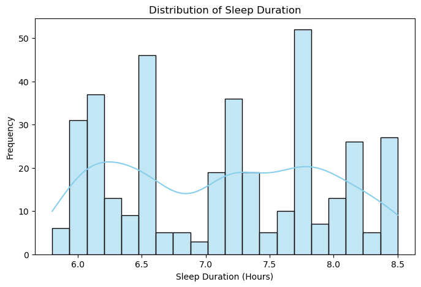

```python
plt.figure(figsize=(8, 5))
sns.histplot(health_df['Sleep Duration'].dropna(), bins=20, kde=True, color='skyblue')
plt.title('Distribution of Sleep Duration')
plt.xlabel('Sleep Duration (Hours)')
plt.ylabel('Frequency')
plt.show()
```

Most individuals in the dataset sleep between 6 and 7.7 hours, with peaks around 6.5 and 7.7 hours, suggesting two main patterns of sleep duration. This could reflect different lifestyle habits or occupational demands among participants.

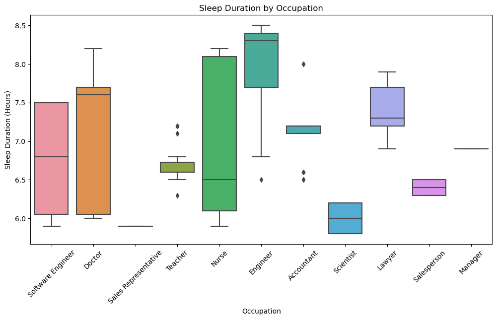

```python
plt.figure(figsize=(12, 6))
sns.boxplot(data=health_df, x='Occupation', y='Sleep Duration')
plt.xticks(rotation=45)
plt.title('Sleep Duration by Occupation')
plt.ylabel('Sleep Duration (Hours)')
plt.xlabel('Occupation')
plt.show()
```

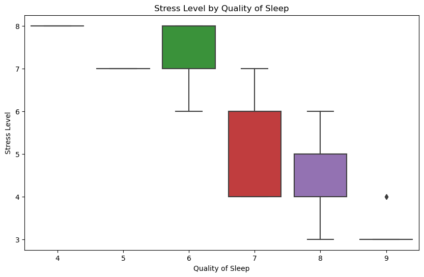

```python
plt.figure(figsize=(10, 6))
sns.boxplot(data=health_df, x='Quality of Sleep', y='Stress Level')
plt.title('Stress Level by Quality of Sleep')
plt.show()
```

Stress levels appear to **decrease steadily as sleep quality improves**. Individuals with poor sleep quality (4-6) consistently report high stress levels (7-8). In contrast, those with excellent sleep quality (8-9) report much lower stress levels (3-5). This suggests a strong inverse relationship between sleep quality and stress.

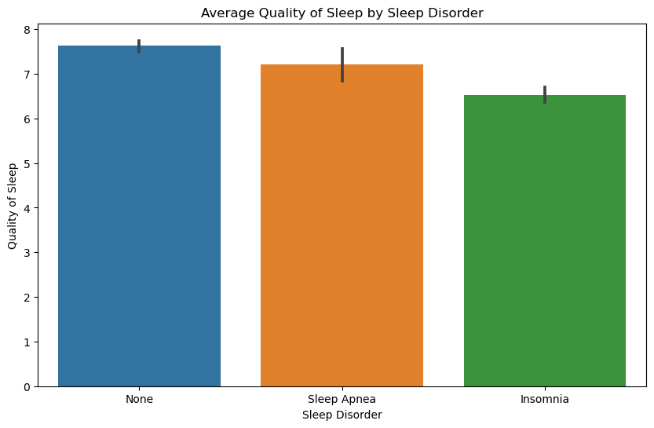

```python
plt.figure(figsize=(10, 6))
sns.barplot(data=health_df, x='Sleep Disorder', y='Quality of Sleep', estimator='mean')
plt.title('Average Quality of Sleep by Sleep Disorder')
plt.show()
```

Individuals without a sleep disorder report the **highest and most consistent sleep quality**. Both sleep apnea and insomnia are associated with lower sleep quality, with insomnia showing the worst average. The skewed distributions suggest that while some individuals with disorders manage decent sleep, the majority experience notably worse quality.

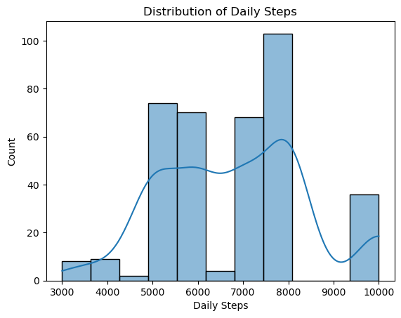

```python
sns.histplot(health_df['Daily Steps'], kde=True)
plt.title('Distribution of Daily Steps')
plt.show()
```

Daily step counts cluster heavily between 5,000 and 7,500, with a sharp peak at 7,500 steps, suggesting it's a common activity target. There's a drop-off between 8,000 and 9,500 steps, which may reflect user behavior, tracking habits, or common goal threshholds. Very high or low step counts are rare.

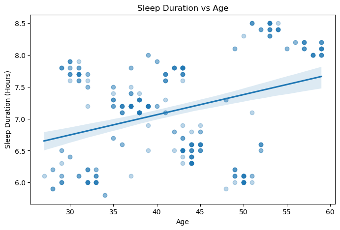

```python
plt.figure(figsize=(8, 5))
sns.regplot(data=health_df, x='Age', y='Sleep Duration', scatter_kws={'alpha':0.3})
plt.title('Sleep Duration vs Age')
plt.xlabel('Age')
plt.ylabel('Sleep Duration (Hours)')
plt.show()
```

Although there's a slight upwards trend in sleep duration with age, the relationship appears **weak due to high variability**. Clustering suggests that factors beyond age such as occupation, stress, or lifestyle likely play a more significant role in determining sleep duration.

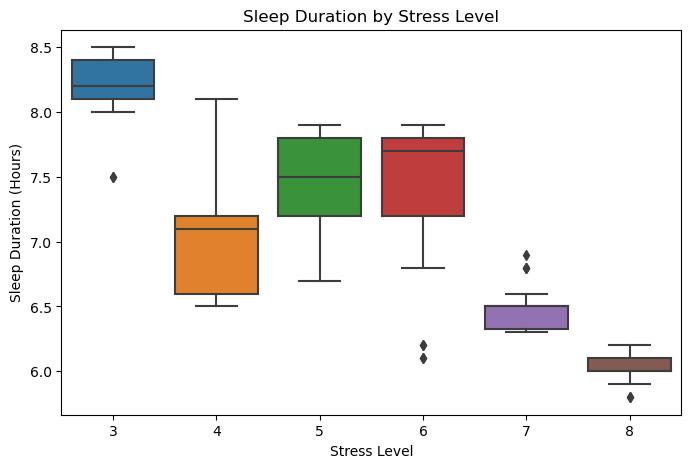

```python
plt.figure(figsize=(8, 5))
sns.boxplot(data=health_df, x='Stress Level', y='Sleep Duration')
plt.title('Sleep Duration by Stress Level')
plt.xlabel('Stress Level')
plt.ylabel('Sleep Duration (Hours)')
plt.show()
```

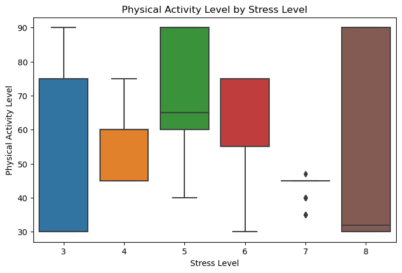

```python
plt.figure(figsize=(8, 5))
sns.boxplot(data=health_df, x='Stress Level', y='Physical Activity Level')
plt.title('Physical Activity Level by Stress Level')
plt.xlabel('Stress Level')
plt.ylabel('Physical Activity Level')
plt.show()
```

Physical activity levels vary across stress groups, but individuals with higher stress (levels 7-8) tend to have lower and less consistent activity. Stress level 7 shows a sharp decline in activity with minimal variation, while level 8 shows a wide spread but low median. In contrast, moderate stress levels (5-6) are associated with higher and more stable activity levels, suggesting a possible buffering effect of regular activity against stress.

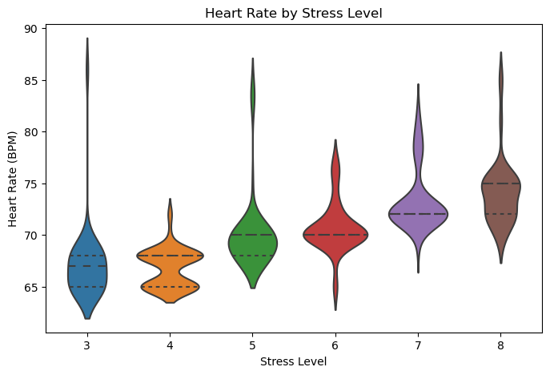

```python
plt.figure(figsize=(8, 5))
sns.violinplot(data=health_df, x='Stress Level', y='Heart Rate', inner='quartile')
plt.title('Heart Rate by Stress Level')
plt.xlabel('Stress Level')
plt.ylabel('Heart Rate (BPM)')
plt.show()
```

The violin plot suggests a **positive correlation between stress level and heart rate**. Lower stress levels (3-5) show more moderate and consistent heart rates, while higher stress levels (6-8) are associated with increased heart rate and greater variability. This supports existing research linking elevated stress with sympathetic nervous system activation and higher resting heart rates.

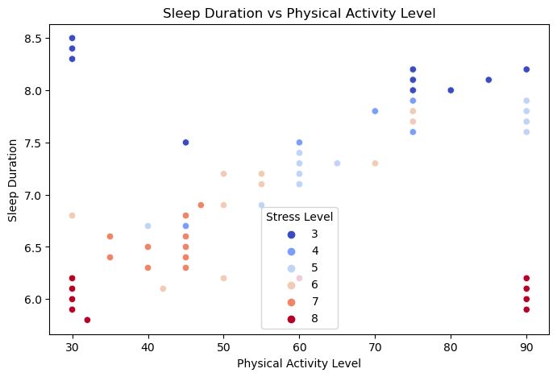

```python
plt.figure(figsize=(8, 5))
sns.scatterplot(data=health_df, x='Physical Activity Level', y='Sleep Duration', hue='Stress Level', palette='coolwarm')
plt.title('Sleep Duration vs Physical Activity Level')
plt.show()
```

The scatter plot reveals that both very high and very low physical activity levels are associated with longer sleep durations in low-stress individuals, while high-stress individuals consistenly report shorter sleep regardless of their activity level. Mid-level activity is more commonly linked with higher stress levels. This suggests that stress may disrupt sleep even when physical activity level is high, and that managing stress may be more important than activity level alone for improving sleep quality.

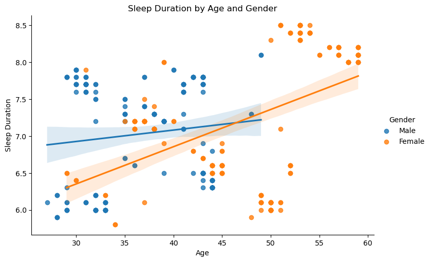

```python
sns.lmplot(data=health_df, x='Age', y='Sleep Duration', hue='Gender', aspect=1.5)
plt.title('Sleep Duration by Age and Gender')
plt.show()
```

The data shows that older females tend to sleep more compared to their younger counterparts, with a wider range in sleep duration. For males, sleep duration increases with age but remains consistent and low overall. The clustering of data suggests that age affects sleep duration differently by gender, with women experiencing greater variation and a more pronounced increase in sleep as they get older.

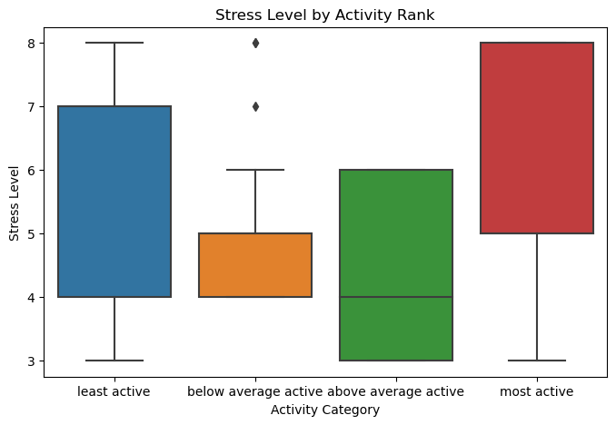

```python
plt.figure(figsize=(8, 5))
sns.boxplot(data=health_df, x='Activity Rank', y='Stress Level', order=activity_rank_label)
plt.title('Stress Level by Activity Rank')
plt.xlabel('Activity Category')
plt.ylabel('Stress Level')
plt.show()
```

There is a variation in stress levels across the activity ranks, with the least active group showing the widest range of stress, including both low and high stress levels. The below average active group has narrower stress levels, but a few outliers suggest that physical activity may not be the only factor affecting their stress. The above average active group shows consistently lower stress levels, supporting the idea that more physical activity could be associated with reduced stress. The most active group displays a wide range of stress levels, indicating that being highly active does not necessarily lead to lower stress for everyone.

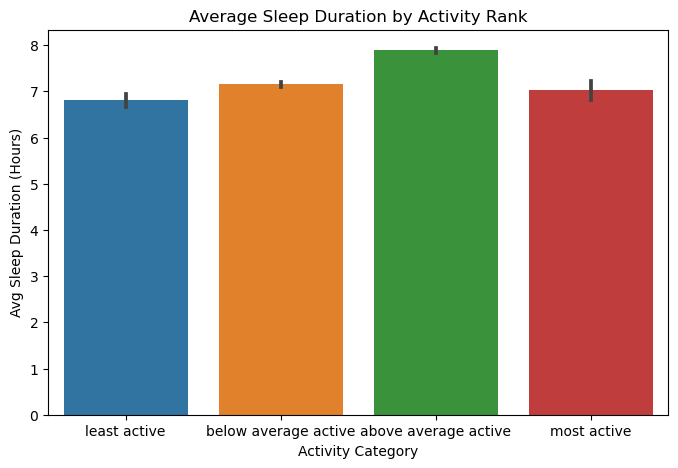

```python
plt.figure(figsize=(8, 5))
sns.barplot(data=health_df, x='Activity Rank', y='Sleep Duration', order=activity_rank_label, estimator=np.mean)
plt.title('Average Sleep Duration by Activity Rank')
plt.xlabel('Activity Category')
plt.ylabel('Avg Sleep Duration (Hours)')
plt.show()
```

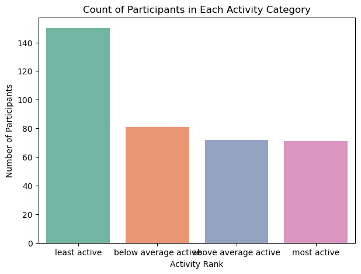

```python
plt.figure(figsize=(7, 5))
sns.countplot(data=health_df, x='Activity Rank', order=activity_rank_label, palette='Set2')
plt.title('Count of Participants in Each Activity Category')
plt.xlabel('Activity Rank')
plt.ylabel('Number of Participants')
plt.show()
```

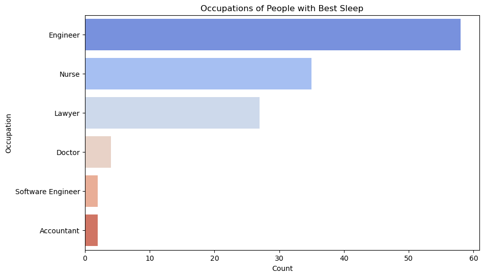

```python
plt.figure(figsize=(10, 6))
sns.countplot(data=best_sleep, y='Occupation', order=best_sleep['Occupation'].value_counts().index, palette='coolwarm')
plt.title('Occupations of People with Best Sleep')
plt.xlabel('Count')
plt.ylabel('Occupation')
plt.show()
```

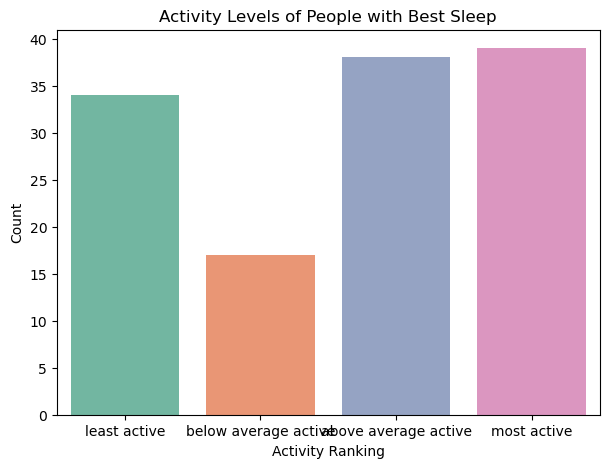

```python
plt.figure(figsize=(7, 5))
sns.countplot(data=best_sleep, x='Activity Ranking', order=activity_rank_label, palette='Set2')
plt.title('Activity Levels of People with Best Sleep')
plt.xlabel('Activity Ranking')
plt.ylabel('Count')
plt.show()
```

A high portion of the more active individuals reported the best sleep, but the least active individuals were not significantly below that, suggesting physical activity may not play a major role in quality of sleep.

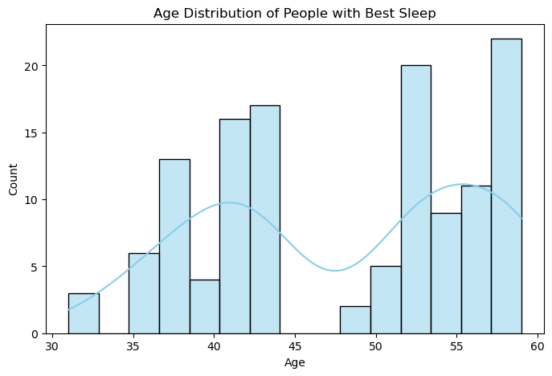

```python
plt.figure(figsize=(8, 5))
sns.histplot(data=best_sleep, x='Age', bins=15, kde=True, color='skyblue')
plt.title('Age Distribution of People with Best Sleep')
plt.xlabel('Age')
plt.ylabel('Count')
plt.show()
```

The age distribution of people with the best sleep is notably higher for individuals in their 50s, with peaks at 53 and 59. This could suggest that people in this age range may experience more consistent or higher quality sleep.

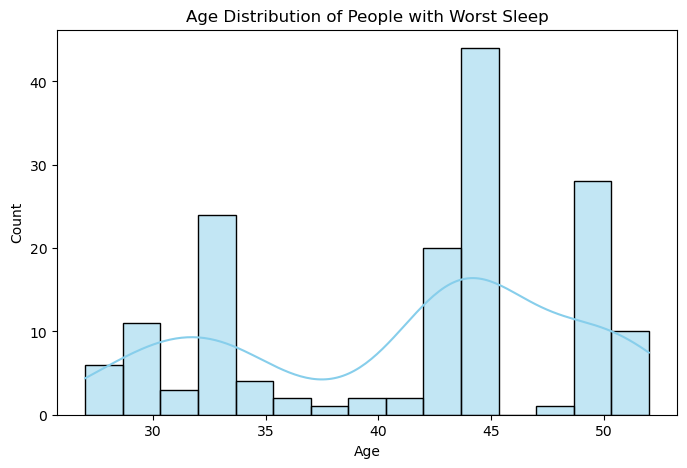

```python
plt.figure(figsize=(8, 5))
sns.histplot(data=worst_sleep, x='Age', bins=15, kde=True, color='skyblue')
plt.title('Age Distribution of People with Worst Sleep')
plt.xlabel('Age')
plt.ylabel('Count')
plt.show()
```

The age distribution of people with the worst sleep peaks heavily at 45. Compared to the distribution for best sleep, the data suggests that sleep improves for individuals after 50 years old.

```python
columns_of_interest = ['Age', 'Sleep Duration', 'Quality of Sleep', 'Physical Activity Level', 'Stress Level', 'Heart Rate', 'Daily Steps']
correlation_matrix = health_df[columns_of_interest].corr()

print("Correlation Matrix:")
print(correlation_matrix)

stress_correlation = correlation_matrix['Stress Level'].drop('Stress Level')
print("\nCorrelation of Stress Level with other variables:")
print(stress_correlation)
```

```
Correlation Matrix:
                              Age  Sleep Duration  Quality of Sleep  \
Age                      1.000000        0.344709          0.473734
Sleep Duration           0.344709        1.000000          0.883213
Quality of Sleep         0.473734        0.883213          1.000000
Physical Activity Level  0.178993        0.212360          0.192896
Stress Level            -0.422344       -0.811023         -0.898752
Heart Rate              -0.225606       -0.516455         -0.659865
Daily Steps              0.057973       -0.039533          0.016791

                         Physical Activity Level  Stress Level  Heart Rate  \
Age                                     0.178993     -0.422344   -0.225606
Sleep Duration                          0.212360     -0.811023   -0.516455
Quality of Sleep                        0.192896     -0.898752   -0.659865
Physical Activity Level                 1.000000     -0.034134    0.136971
Stress Level                           -0.034134      1.000000    0.670026
Heart Rate                              0.136971      0.670026    1.000000
Daily Steps                             0.772723      0.186829   -0.030309

                         Daily Steps
Age                         0.057973
Sleep Duration             -0.039533
Quality of Sleep            0.016791
Physical Activity Level     0.772723
Stress Level                0.186829
Heart Rate                 -0.030309
Daily Steps                 1.000000

Correlation of Stress Level with other variables:
Age                       -0.422344
Sleep Duration            -0.811023
Quality of Sleep          -0.898752
Physical Activity Level   -0.034134
Heart Rate                 0.670026
Daily Steps                0.186829
Name: Stress Level, dtype: float64
```

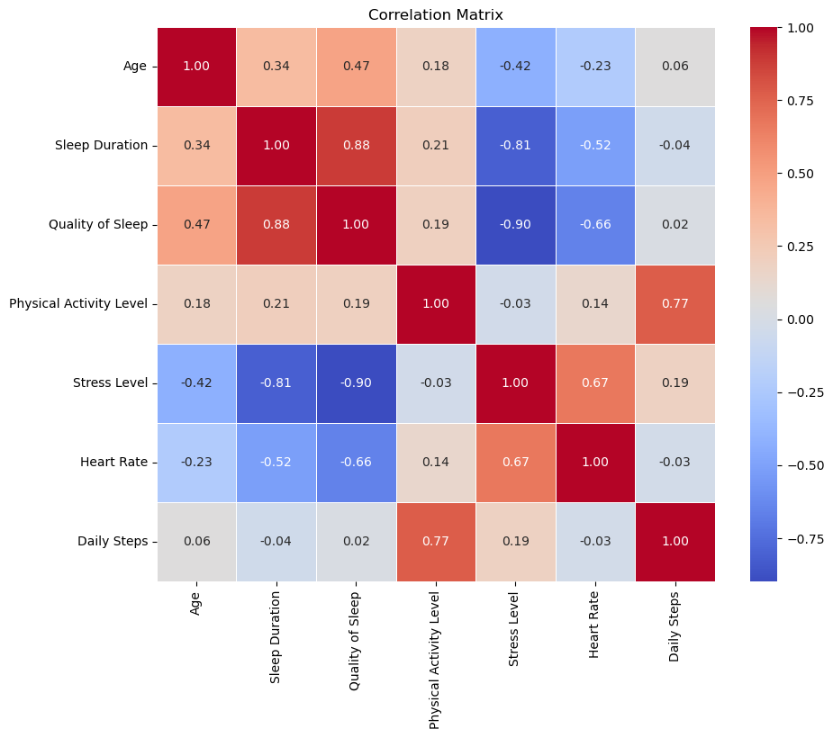

```python
plt.figure(figsize=(10, 8))

sns.heatmap(correlation_matrix, annot=True, cmap='coolwarm', fmt=".2f", linewidths=0.5)

plt.title('Correlation Matrix')

plt.show()
```

```python
stress_correlation_data = {
    'Age': -0.422344,
    'Sleep Duration': -0.811023,
    'Quality of Sleep': -0.898752,
    'Physical Activity Level': -0.034134,
    'Heart Rate': 0.670026,
    'Daily Steps': 0.186829
}
stress_correlation_df = pd.DataFrame(stress_correlation_data, index=[0])
stress_correlation_df
```

|  | Age | Sleep Duration | Quality of Sleep | Physical Activity Level | Heart Rate | Daily Steps |
| --- | --- | --- | --- | --- | --- | --- |
| 0 | -0.422344 | -0.811023 | -0.898752 | -0.034134 | 0.670026 | 0.186829 |

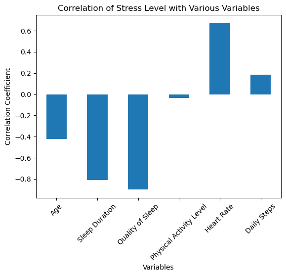

```python
stress_correlation_df = stress_correlation_df.transpose()

plt.figure(figsize=(10, 6))
stress_correlation_df.plot(kind='bar', legend=None)
plt.title('Correlation of Stress Level with Various Variables')
plt.xlabel('Variables')
plt.ylabel('Correlation Coefficient')
plt.xticks(rotation=45)
plt.show()
```

### Age and Stress Level (-0.422344):

This correlation coefficient indicates a moderate negative correlation between Age and Stress Level. Interpretation: As Age increases, Stress Level tends to decrease moderately. Younger individuals may experience higher stress levels compared to older individuals. This is consistent with the visualization showing that older individuals tend to report lower stress levels, further highlighting the potential role of age in stress management.

### Sleep Duration and Stress Level (-0.811023):

This correlation coefficient indicates a strong negative correlation between Sleep Duration and Stress Level. Interpretation: As Sleep Duration increases, Stress Level tends to decrease significantly. Individuals who sleep longer may experience lower stress levels. The visualizations also show that individuals with the best sleep patterns tend to report lower stress levels, supporting this correlation. Longer sleep duration appears to be a key factor in stress reduction.

### Quality of Sleep and Stress Level (-0.898752):

This correlation coefficient indicates a very strong negative correlation between Quality of Sleep and Stress Level. Interpretation: As the Quality of Sleep improves, Stress Level tends to decrease considerably. This suggests that individuals with higher-quality sleep tend to experience lower stress levels. This finding is further supported by the visualization of occupations with the best sleep, showing that certain occupations tend to correlate with better sleep and lower stress levels.

### Physical Activity Level and Stress Level (-0.034134):

This correlation coefficient indicates a very weak negative correlation between Physical Activity Level and Stress Level. Interpretation: There is almost no relationship between Physical Activity Level and Stress Level based on this correlation. The scatter plot visualizations show that physical activity levels are more spread out across stress levels, with little indication that increased physical activity significantly impacts stress levels in this dataset. This suggests that factors like sleep quality may play a more prominent role in stress reduction.

### Heart Rate and Stress Level (0.670026):

This correlation coefficient indicates a moderate positive correlation between Heart Rate and Stress Level. Interpretation: As Heart Rate increases, Stress Level tends to increase moderately. Individuals with higher heart rates may experience higher stress levels. The violin plot shows a wider distribution of heart rates at higher stress levels, supporting the idea that physiological responses (like heart rate) are more variable under stress, and this variability might increase as stress levels rise.

### Daily Steps and Stress Level (0.186829):

This correlation coefficient indicates a weak positive correlation between Daily Steps and Stress Level. Interpretation: There is a slight tendency for Stress Level to increase slightly as Daily Steps increase. However, the correlation is relatively weak, suggesting that the relationship between Daily Steps and Stress Level is not very strong. The scatter plot of physical activity vs. stress further indicates that while activity levels vary, they don’t strongly correlate with stress, reinforcing the idea that other factors, such as sleep, might have a more significant impact.